# OLS & interactions: Students’ life satisfaction in Finland

## Visualization of interaction effect

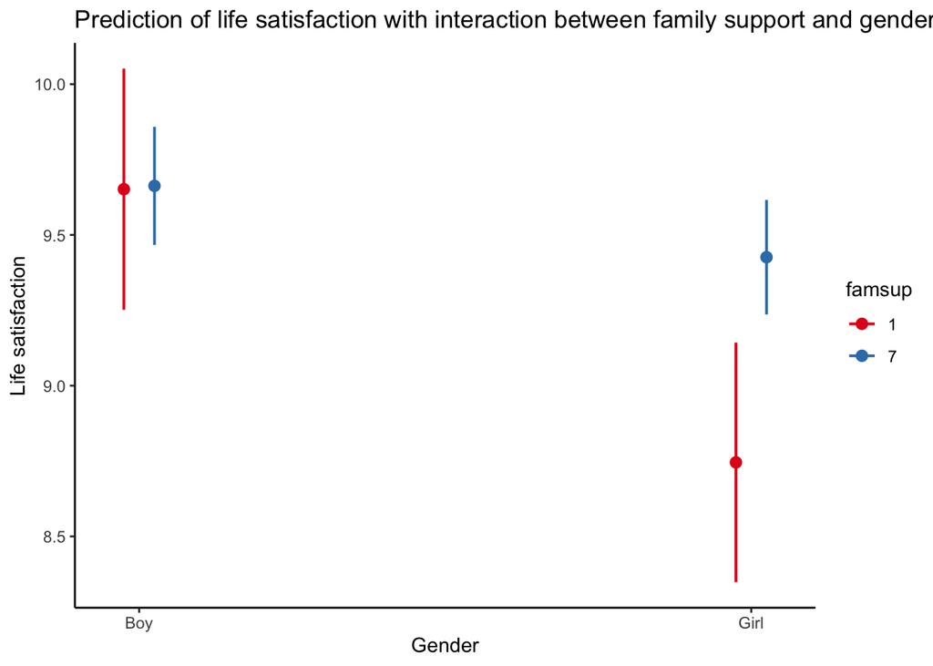

```r
library(sjPlot)
library(ggplot2)
plot_model(model_interaction, type="int", title = "Prediction of life satisfaction with interaction between family support and gender", colors = "Set1") + ylab("Life satisfaction") +
  theme_classic()
```

- For girls higher family support results in higher life satisfaction as confidence intervals do not overlap at all.
- For boys changes in family support do not result in changes in life satisfaction as confidence intervals do overlap.

# Check for a non-linear effect in the model

Let’s try Box-Tidwell test to check whether the relationship between continuous predictors and outcome variable is linear.

(I do not know why, but this function does not work if I put several or all variables at once, but it is a common problem according to Stack overflow)

```r
library(car)
boxTidwell(lifesat ~ famtalk + friendcounton, data = df)
```

```
##               MLE of lambda Score Statistic (z)  Pr(>|z|)
## famtalk              2.6653             10.3488 < 2.2e-16 ***
## friendcounton        3.9249              4.8501 1.234e-06 ***
## ---
## Signif. codes:  0 '***' 0.001 '**' 0.01 '*' 0.05 '.' 0.1 ' ' 1
##
## iterations =  26
```

- P-value here indicates whether our model will become significantly better if we transform the corresponding variables.
- According to MLE of lambda, `famtalk` can be transformed to quadratic term as it equals approximately to 2, but we should not do transformation with `friendcounton` as MLE of lambda is too high (4), so there is no sense to do smth.

```r
library(car)
boxTidwell(lifesat ~ famhelp + friendtalk, data = df)
```

```
##            MLE of lambda Score Statistic (z) Pr(>|z|)
## famhelp          3.79467             14.8309   <2e-16 ***
## friendtalk       0.36403             -0.2453   0.8062
## ---
## Signif. codes:  0 '***' 0.001 '**' 0.01 '*' 0.05 '.' 0.1 ' ' 1
##
## iterations =  26
```

- `famhelp` has the corresponding very small p-value, but we should not do smth with this predictor as MLE of lambda is too high.
- p-value for `friendtalk` indicates that the model would not become significantly better if this variable is transformed.

```r
library(car)
boxTidwell(lifesat ~ famsup, data = df)
```

```
##  MLE of lambda Score Statistic (z)  Pr(>|z|)
##         3.4417              16.927 < 2.2e-16 ***
## ---
## Signif. codes:  0 '***' 0.001 '**' 0.01 '*' 0.05 '.' 0.1 ' ' 1
##
## iterations =  8
```

- `famsup` has the corresponding very small p-value, but we should not do smth with this predictor as MLE of lambda is too high.

```r
boxTidwell(lifesat ~ friendhelp, data = df)
```

```
##  MLE of lambda Score Statistic (z)  Pr(>|z|)
##         1.7882              4.0015 6.295e-05 ***
## ---
## Signif. codes:  0 '***' 0.001 '**' 0.01 '*' 0.05 '.' 0.1 ' ' 1
##
## iterations =  7
```

- `friendhelp` should be transformed to quadratic term as it equals approximately to 2.

Therefore, `famtalk` and `friendhelp` indeed have quadratic relationship with dependent variable, rather than linear.

# Third model with quadratic transformation of `famtalk` & `friendhelp`

```r
labs_2 <-  c("Constant", "Gender (Girl)",
                "Age category (13)", "Age category (15)",
            "Family help", "Family support", "Family talk", "Family talk^2", "Friends' help", "Friends' help^2", "Friends count on", "Friends Talk", "Teacher cares (Agree)", "Teacher cares (Neither agree/disagree)", "Teacher cares (Strongly disagree)", "Students are kind and helpful", "Liking school (Like a bit)", "Liking school (Not very much)", "Liking school (Not at all)", "Family well off (Quite well off)", "Family well off (Quite well off)", "Family well off (Average)", "Family well off (Not very well off)", "Family well off (Not at all well off)", "Family holidays (Once)", "Family holidays (Twice)", "Family holidays (More than twice)", "Has own bedroom (Yes)", "Gender(Girl)*Family support")


model_3 <- lm(lifesat ~ sex + AGECAT + famhelp + famsup*sex + famtalk + I(famtalk^2) + friendhelp + I(friendhelp^2) + friendcounton + friendtalk + teachercare + studhelpful + likeschool + welloff + fasholidays + fasbedroom, data = df)


tab_model(model_3, pred.labels = labs_2, dv.labels = "Life Satisfaction", title = "Linear regression with interaction: Factors that are associated with life satisfaction")
```

Linear regression with interaction: Factors that are associated with life satisfaction

|  | Life Satisfaction |  |  |
| --- | --- | --- | --- |
| Predictors | Estimates | CI | p |
| Constant | 9.53 | 9.16 – 9.91 | **<0.001** |
| Gender (Girl) | -0.99 | -1.28 – -0.69 | **<0.001** |
| Age category (13) | 0.03 | -0.07 – 0.12 | 0.592 |
| Age category (15) | 0.06 | -0.04 – 0.15 | 0.256 |
| Family help | -0.03 | -0.09 – 0.03 | 0.289 |
| Family support | 0.03 | -0.05 – 0.10 | 0.439 |
| Family talk | -0.24 | -0.38 – -0.10 | **0.001** |
| Family talk^2 | 0.04 | 0.03 – 0.06 | **<0.001** |
| Friends’ help | -0.18 | -0.32 – -0.04 | **0.015** |
| Friends’ help^2 | 0.02 | 0.01 – 0.03 | **0.005** |
| Friends count on | 0.10 | 0.04 – 0.15 | **<0.001** |
| Friends Talk | -0.02 | -0.06 – 0.02 | 0.254 |
| Teacher cares (Agree) | -0.06 | -0.17 – 0.05 | 0.271 |
| Teacher cares (Neither agree/disagree) | -0.19 | -0.30 – -0.07 | **0.002** |
| Teacher cares (Strongly disagree) | -0.57 | -0.76 – -0.39 | **<0.001** |
| Students are kind and helpful | -0.56 | -0.79 – -0.34 | **<0.001** |
| Liking school (Like a bit) | -0.12 | -0.16 – -0.08 | **<0.001** |
| Liking school (Not very much) | -0.30 | -0.42 – -0.18 | **<0.001** |
| Liking school (Not at all) | -0.76 | -0.89 – -0.62 | **<0.001** |
| Family well off (Quite well off) | -1.30 | -1.49 – -1.11 | **<0.001** |
| Family well off (Quite well off) | -0.19 | -0.28 – -0.10 | **<0.001** |
| Family well off (Average) | -0.50 | -0.61 – -0.39 | **<0.001** |
| Family well off (Not very well off) | -1.32 | -1.50 – -1.14 | **<0.001** |
| Family well off (Not at all well off) | -1.35 | -1.84 – -0.85 | **<0.001** |
| Family holidays (Once) | 0.08 | -0.01 – 0.17 | 0.087 |
| Family holidays (Twice) | 0.11 | 0.00 – 0.22 | **0.042** |
| Family holidays (More than twice) | 0.11 | -0.02 – 0.24 | 0.105 |
| Has own bedroom (Yes) | 0.11 | -0.00 – 0.22 | 0.054 |
| Gender(Girl)*Family support | 0.10 | 0.06 – 0.15 | **<0.001** |
| Observations | 5541 |  |  |
| R<sup>2</sup> / R<sup>2</sup> adjusted | 0.297 / 0.294 |  |  |

- Adjusted R-squared equals to 0.294, which is a little bit higher than for the second model with interaction effect that do not assume quadratic relationship (0.286).
- P-values for both transformed variables indicate that there is actually a quadratic relationship between each of them and life satisfaction of finnish adolescents.

# Comparing models

Choose the best model.

```r
anova(model_full, model_interaction, model_3)
```

```
## Analysis of Variance Table
##
## Model 1: lifesat ~ sex + AGECAT + famhelp + famsup + famtalk + friendhelp +
##     friendcounton + friendtalk + teachercare + studhelpful +
##     likeschool + welloff + fasholidays + fasbedroom
## Model 2: lifesat ~ sex + AGECAT + famhelp + famsup * sex + famtalk + friendhelp +
##     friendcounton + friendtalk + teachercare + studhelpful +
##     likeschool + welloff + fasholidays + fasbedroom
## Model 3: lifesat ~ sex + AGECAT + famhelp + famsup * sex + famtalk + I(famtalk^2) +
##     friendhelp + I(friendhelp^2) + friendcounton + friendtalk +
##     teachercare + studhelpful + likeschool + welloff + fasholidays +
##     fasbedroom
##   Res.Df   RSS Df Sum of Sq      F    Pr(>F)
## 1   5515 10827
## 2   5514 10786  1    40.522 20.942 4.838e-06 ***
## 3   5512 10666  2   121.004 31.268 3.140e-14 ***
## ---
## Signif. codes:  0 '***' 0.001 '**' 0.01 '*' 0.05 '.' 0.1 ' ' 1
```

The third model is the best at predicting life satisfaction of finnish adolescents according to small p-value and decreased RSS.

# Check problems in the best model

## Normal distribution of residuals

### Q-Q plot

- ols_test_normality works only for sample size between 3 and 5000, but our equals to 5541, so let’s skip it.

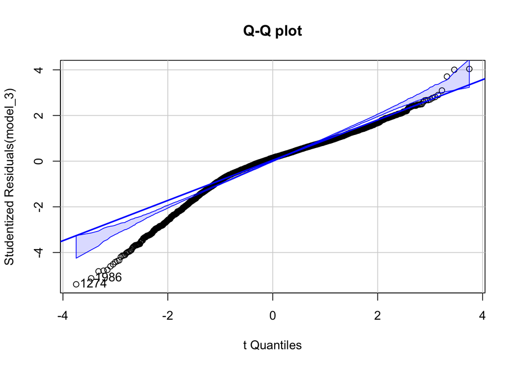

```
## [1] 1274 1986
```

```r
qqPlot(model_3, labels = row.names(lifesat), main = "Q-Q plot")
```

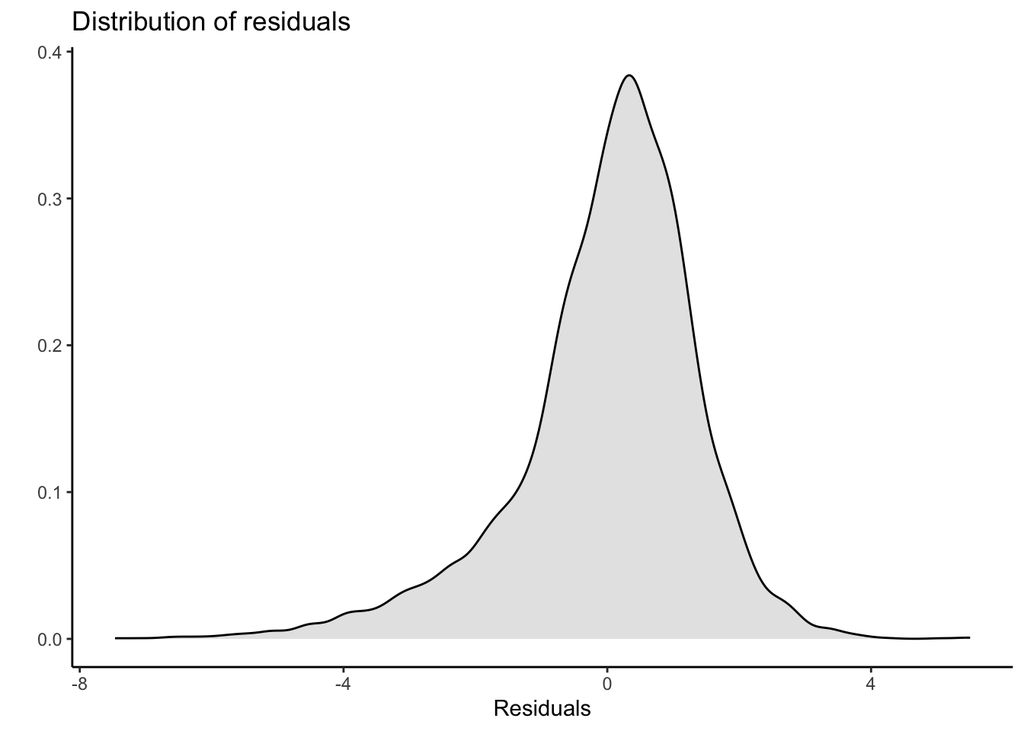

```r
ggplot(df, aes(residuals(model_3))) +
  geom_density(fill = "#e5e5e5") +
labs(x = "Residuals",
     y = " " ,
     title = "Distribution of residuals") +
   theme_classic()
```

- The distribution of residuals is skewed to the left as there is this heavy left tail.
- I can conclude that residuals are not normally distributed.

Let’s look at outliers to see how much they are problematic in terms of the difference with other observations.

## Outliers

```r
outlierTest(model_3)
```

```
##       rstudent unadjusted p-value Bonferroni p
## 1274 -5.394313         7.1656e-08   0.00039705
## 1986 -5.131641         2.9707e-07   0.00164610
## 976  -4.825924         1.4311e-06   0.00792990
## 2977 -4.798761         1.6386e-06   0.00907960
## 4885 -4.759498         1.9903e-06   0.01102800
## 4264 -4.607569         4.1658e-06   0.02308300
## 1717 -4.518534         6.3570e-06   0.03522400
```

- There are 7 outliers in the data, which is a problem.

### Leverages

Leverages are the values that are very different from the rest of a sample.

```r
head(hatvalues(model_3))
```

```
##           1           2           3           4           5           6
## 0.004143238 0.003121006 0.005207636 0.004755580 0.003237323 0.004800542
```

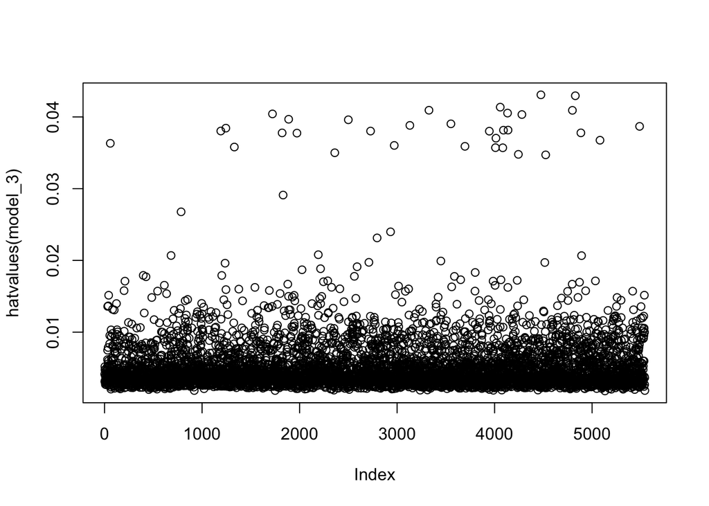

```r
plot(hatvalues(model_3))
```

Hat values should be close to 0. They show how far from the rest of observations certain observations. To determine whether such distribution is okay or nor let’s draw threshold lines.

(2,3)*((k + 1)/n), where k - number of beta-coefficients, n - sample size

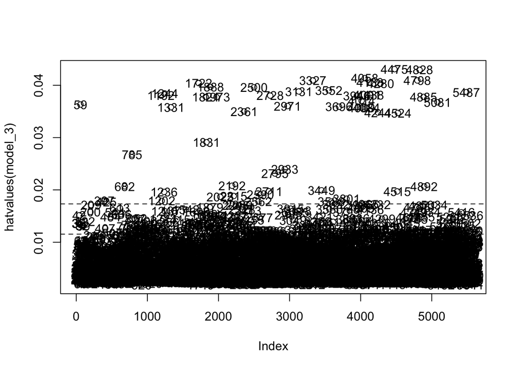

```r
plot(hatvalues(model_3))
abline(h = c(2,3)*32/5541, lty = 2)
text(hatvalues(model_3), rownames(df$lifesat))
```

### Cook’s distance

The model does not fit well for all observations located above the lines.

How much fitted values would change if we delete certain problematic observations.

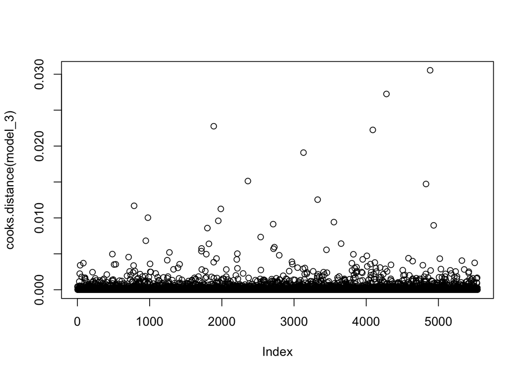

```r
plot(cooks.distance(model_3))
```

To determine the threshold we should apply the following function: 4/(n-k-1)

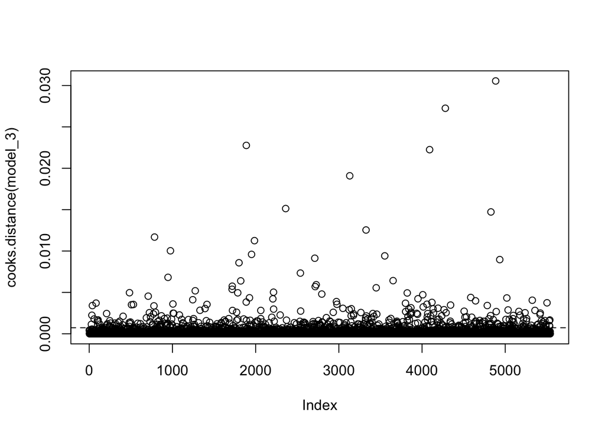

```r
plot(cooks.distance(model_3))
abline(h=4/(5541 - 31 - 1), lty = 2)
```

There are quite a lot of observation located above the dotted line - threshold.

Now let’s try combine the result of cook’s distance and hat values!

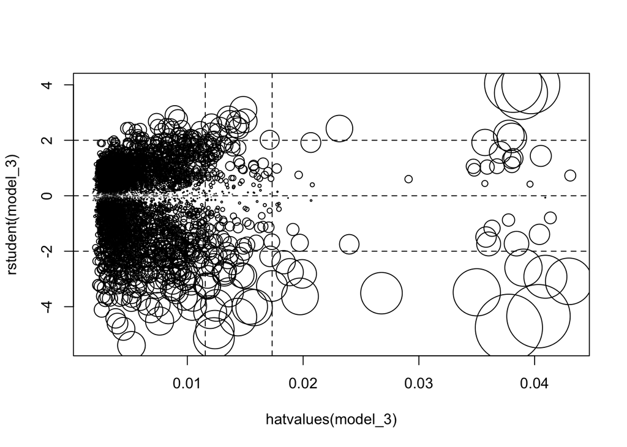

```r
plot(hatvalues(model_3), rstudent(model_3), type = "n")
# threshold for residuals
abline(h=c(-2, 0, 2), lty = 2)
# threshold for leverages
abline(v = c(2,3)*32/5541, lty = 2)
cook <- sqrt(cooks.distance(model_3))
points(hatvalues(model_3), rstudent(model_3), cex = 10*cook/max(cook))
text(hatvalues(model_3), rstudent(model_3), rownames(df$lifesat))
```

As we can see there are a lot of observations which standardized residuals less than -2. The most problematic observations are in the bottom right part of rectangular and in the upper right part. Rectangular indicates the part where observations with high leverages lie. Problematic observations that are found by cook-distance are indicated by the big size of the nodes.